# Library Generation Rapid Biosensor

Niklas Rindtorff CostItem: 5000610

## Specify final assay plate layout

We are going to create a compound library consisting of:

- 3 sectors
- 7 compounds + a negative/positive control
- 8 concentrations
- 2 technical replicates

First, I am going to design the final layout. Afterwards, I am going to specify a source plate layout that is compatible. Prior approaches, based on using a fixed source concentration and a variable volume turned out to be unfeasable.

First I define sections that are going to be populated with different cell types.

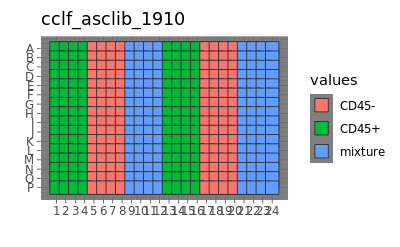

```r
lib_pre <- tibble(well = num_to_well(1:384, plate = 384)) %>%
  separate(well, c("row", "col_pad"), remove = FALSE, sep = 1) %>%
  mutate(col = as.numeric(col_pad)) %>%
  mutate(row = as.character(row),
         sample = case_when(
           col %in% c(1:4, 13:16) ~ "CD45+",
           col %in% c(5:8, 17:20) ~ "CD45-",
           TRUE ~ "mixture"
         ))

df = lib_pre
raw_map(data = df$sample,
        well = df$well,
        plate = 384) +
    ggtitle("cclf_asclib_1910") +
    theme_dark()
```

Now I define a vector with 128 elements and a random set of compound identifiers, and concentration factors.

The minimal volume (in Liters) that can be handled by the Echo is:

```r
lw <- 2.5E-9
lw
```

```
[1] 2.5e-09
```

My concentrations/ volumes are going to be:

```r
vol_well = 60E-6
dil_fact = 1000
stock = 10E-3
mid <- vol_well/dil_fact
#fixed-concentration approach
# conc <- tibble(x = c(1:8),
#        x2 = 2^x,
#        fac = x2/32,
#        vol_l = fac*mid,
#        dil_fac = vol_l/vol_well,
#        f_conc_uM = dil_fac*stock*1E6) %>%
#   dplyr::select(concentration = x, vol_l, f_conc_uM ) %>%
#   mutate(i_conc_mM = 2E-3*1000)
#fixed volume approach
conc <- tibble(x = c(1:8),
               f_conc_uM = stock/(2^(x-1))*1000) %>%
  dplyr::select(concentration = x,  f_conc_uM ) %>%
  mutate(i_conc_mM = stock*1000)
conc
```

| concentration | f_conc_uM | i_conc_mM |
| --- | --- | --- |
| 1 | 10.000000 | 10 |
| 2 | 5.000000 | 10 |
| 3 | 2.500000 | 10 |
| 4 | 1.250000 | 10 |
| 5 | 0.625000 | 10 |
| 6 | 0.312500 | 10 |
| 7 | 0.156250 | 10 |
| 8 | 0.078125 | 10 |

The default stock concentration is going to be [mM]:

```r
stock*1000
```

```
[1] 10
```

The dispensing volume is going to be [nl]:

```r
vol_disp = vol_well/1000
vol_disp*1E9
```

```
[1] 60
```

```r
#test
#stopifnot(min(conc$vol_l) >=  lw)
```

```r
#I set a seed
set.seed(7)
#I define my element
df <- expand.grid(compound = LETTERS[1:8],
                  concentration = 1:8,
                  replicate = 1:2) %>%
  mutate(compound = ifelse(compound == "H", "CTRL", LETTERS[compound]),
         compound = ifelse(compound == "CTRL" & concentration %in% c(1:4), "Stauro", compound),
         compound = ifelse(compound == "CTRL" & concentration %in% c(5:8), "DMSO", compound)) %>%
          sample_frac(1) %>%
  mutate(concentration = ifelse(compound %in% c("Stauro", "DMSO"), NA, concentration))
```

I merge the sectioned layout with the drug IDs and concentration IDs. This is my final layout.

```r
#I nest items
lib <- lib_pre %>%
  nest(-sample) %>%
  #I cbind my 128 element long element, which I define below
  mutate(new = map(data, ~cbind(.x, df))) %>%
  unnest(new) %>%
  left_join(conc)
lib %>% dplyr::select(-replicate, -sample)
```

| well | row | col_pad | col | compound | concentration | f_conc_uM | i_conc_mM |
| --- | --- | --- | --- | --- | --- | --- | --- |
| A01 | A | 01 | 1 | G | 8 | 0.078125 | 10 |
| A02 | A | 02 | 2 | C | 7 | 0.156250 | 10 |
| A03 | A | 03 | 3 | G | 2 | 5.000000 | 10 |
| A04 | A | 04 | 4 | A | 2 | 5.000000 | 10 |
| A13 | A | 13 | 13 | G | 4 | 1.250000 | 10 |
| A14 | A | 14 | 14 | B | 5 | 0.625000 | 10 |
| A15 | A | 15 | 15 | B | 6 | 0.312500 | 10 |
| A16 | A | 16 | 16 | F | 7 | 0.156250 | 10 |
| B01 | B | 01 | 1 | D | 3 | 2.500000 | 10 |
| B02 | B | 02 | 2 | G | 7 | 0.156250 | 10 |

[output cut: 374 more lines]

Here all concentrations are color-coded.

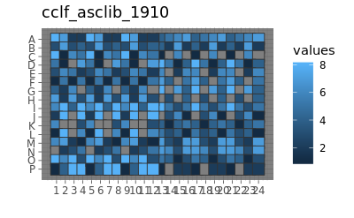

```r
df = lib
raw_map(data = df$concentration,
        well = df$well,
        plate = 384) +
    ggtitle("cclf_asclib_1910") +
    theme_dark()
```

Here all compounds have a unique color.

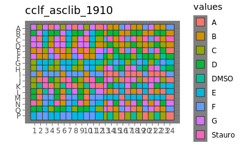

```r
raw_map(data = df$compound,
        well = df$well,
        plate = 384) +
    ggtitle("cclf_asclib_1910") +
    theme_dark()
```

```r
lib %>%
  dplyr::select(-replicate, -sample) %>%
  write_excel_csv("cclf_ascites_1910.csv")
```

## Specify source plate

The source plate for the Echo system will follow a **B40** layout with the following modifications:

- I will only test 7 compounds instead of 40. A large fraction of wells will be empty/ filled with DMSO
- I will dispense both DMSO and Water based compound. Thus, I will need two source plates!
- The control compounds are in the first two columns of the DMSO source plate

```r
#knitr::include_graphics(here("book/local_data/b40.png"))
```

```r
source_plate <- expand.grid(c("A03", "A13", "A04", "A14", "B03", "B13", "B04", "B14") %>%
              substr(., 2,3) %>% unique(),
              LETTERS[1:14]) %>%
  set_colnames(c("source_col", "source_row")) %>%
  cbind(compound = rep(c(LETTERS[1:7]), each = 8)) %>%
  cbind(concentration = rep(c(1:8), times = 7)) %>%
  mutate(source_well = paste0(source_row, source_col)) %>%
  mutate(solvent = if_else(compound == "G", "H20_based", "DMSO_based")) %>%
  dplyr::select(-source_col, -source_row) %>%
  #Now I need to add a column for negative and positive controls.
  rbind(., expand.grid(source_col = c("01","02"),
                      source_row = LETTERS[1:16]) %>%
          mutate(source_well = paste0(source_row, source_col)) %>%
          mutate(compound = if_else(source_col == "02", "DMSO", "Stauro")) %>%
          mutate(concentration = NA) %>%
          mutate(solvent = "DMSO_based") %>%
          dplyr::select(-source_col, -source_row))

source_plate
```

| compound | concentration | source_well | solvent |
| --- | --- | --- | --- |
| A | 1 | A03 | DMSO_based |
| A | 2 | A13 | DMSO_based |
| A | 3 | A04 | DMSO_based |
| A | 4 | A14 | DMSO_based |
| A | 5 | B03 | DMSO_based |
| A | 6 | B13 | DMSO_based |
| A | 7 | B04 | DMSO_based |
| A | 8 | B14 | DMSO_based |
| B | 1 | C03 | DMSO_based |
| B | 2 | C13 | DMSO_based |

[output cut: 78 more lines]

Below I plot the layout for the two source plates: * Source plate “DMSO” * Source plate “H20”

First Source plate “DMSO”

[output not shown]

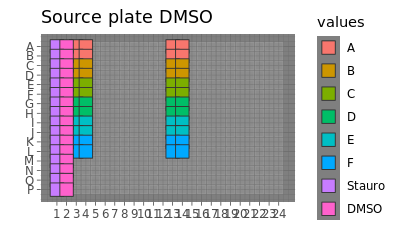

```r
df <- source_plate %>% filter(solvent == "DMSO_based")
raw_map(data = df$compound,
        well = df$source_well,
        plate = 384) +
    ggtitle("Source plate DMSO") +
    theme_dark()
```

Dark values correspond to high concentrations of the drug.

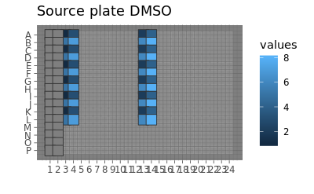

```r
df <- source_plate %>% filter(solvent == "DMSO_based")
raw_map(data = df$concentration,
        well = df$source_well,
        plate = 384) +
    ggtitle("Source plate DMSO") +
    theme_dark()
```

Now the Source plate H20:

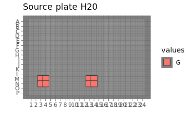

```r
df <- source_plate %>% filter(solvent == "H20_based")
raw_map(data = df$compound,
        well = df$source_well,
        plate = 384) +
    ggtitle("Source plate H20") +
    theme_dark()
```

[output not shown]

[output cut: 78 more lines]

## Add artificial concentrations to controls

In order to not have one control be sourced from multiple wells, I have to randomly assign control wells to source wells using concentration identifiers.

| compound | source_well | solvent | concentration |
| --- | --- | --- | --- |
| Stauro | A01 | DMSO_based | 1 |
| Stauro | B01 | DMSO_based | 2 |
| Stauro | C01 | DMSO_based | 3 |
| Stauro | D01 | DMSO_based | 4 |
| Stauro | E01 | DMSO_based | 5 |
| Stauro | F01 | DMSO_based | 6 |
| Stauro | G01 | DMSO_based | 7 |
| Stauro | H01 | DMSO_based | 8 |
| Stauro | I01 | DMSO_based | 9 |
| Stauro | J01 | DMSO_based | 10 |

[output cut: 78 more lines]

## Create final worklists

| destination_well | source_well | solvent | volume_nl |
| --- | --- | --- | --- |
| D03 | A02 | DMSO_based | 60 |
| F15 | B02 | DMSO_based | 60 |
| G04 | C02 | DMSO_based | 60 |
| G14 | D02 | DMSO_based | 60 |
| H15 | E02 | DMSO_based | 60 |
| K02 | F02 | DMSO_based | 60 |
| L03 | G02 | DMSO_based | 60 |
| P14 | H02 | DMSO_based | 60 |
| D07 | I02 | DMSO_based | 60 |
| F19 | J02 | DMSO_based | 60 |

[output cut: 374 more lines]

Writing the source file.

## Final comments

- I will provide ~ 1ml of each compound (new order)